# 重賞レース予測レポート【毎時自動更新中】

作成日時: 2026/08/09 14:07:52

☞ [マニュアル(pdf)](https://ryutoro-galois.github.io/keiba-predictor/manual/manual.pdf)

☞ 過去6年の同一レース結果: [2025年](https://ryutoro-galois.github.io/keiba-predictor/report/PredResult_2025y_raceDate_20250809_20250810.html), [2024年](https://ryutoro-galois.github.io/keiba-predictor/report/PredResult_2024y_raceDate_20240804_20240804.html), [2023年](https://ryutoro-galois.github.io/keiba-predictor/report/PredResult_2023y_raceDate_20230806_20230806.html), [2022年](https://ryutoro-galois.github.io/keiba-predictor/report/PredResult_2022y_raceDate_20220807_20220807.html), [2021年](https://ryutoro-galois.github.io/keiba-predictor/report/PredResult_2021y_raceDate_20210808_20210808.html), [2020年](https://ryutoro-galois.github.io/keiba-predictor/report/PredResult_2020y_raceDate_20200809_20200809.html)

☞ 過去4週間の別レース結果: [1週前(8/2)](https://ryutoro-galois.github.io/keiba-predictor/report/PredResult_2026y_raceDate_20260802_20260802.html), [2週前(7/26)](https://ryutoro-galois.github.io/keiba-predictor/report/PredResult_2026y_raceDate_20260726_20260726.html), [3週前(7/19)](https://ryutoro-galois.github.io/keiba-predictor/report/PredResult_2026y_raceDate_20260719_20260719.html), [4週前(7/12)](https://ryutoro-galois.github.io/keiba-predictor/report/PredResult_2026y_raceDate_20260712_20260712.html)

☞ netkeiba: [エルムステークス(GⅢ)](https://race.netkeiba.com/race/shutuba.html?race_id=202601010511&rf=race_list), [レパードステークス(GⅢ)](https://race.netkeiba.com/race/shutuba.html?race_id=202604020607&rf=race_list), [CBC賞(GⅢ)](https://race.netkeiba.com/race/shutuba.html?race_id=202607020607&rf=race_list)

## 0. 推し馬予測 (AI予測)

### 【エルムステークス(GⅢ) 2026/08/08(土)】

- 本命(◎): 1-3着内確率(勝負強さ)が1位の馬
- 対抗(◯): 1-3着内確率が2-N位(20%程度以上)の中で予測タイムが最も速い馬
- 3番手(▲): 1-3着内確率が2-N位(20%程度以上)のでダークホース確率が最も高い馬
- 穴: ダークホース確率が上位1-M位(40%程度以上)の中で1-3着内確率が最も高い馬

| 推し馬 | 枠番 | 馬番 | 人気 | オッズ | 馬名 | 騎手 | 調教師 | 予測タイム(sec) | 1_順位 | 1-3着内確率(%) | 2_順位 | ﾀﾞｰｸﾎｰｽ確率(%) | 3_順位 |
| --- | --- | --- | --- | --- | --- | --- | --- | --- | --- | --- | --- | --- | --- |
| 本命(◎) | 5 | 5 | 2 | 4.3 | テーオーパスワード | 松山弘平 | 高柳大輔 | 104.7 | 5 | 49.2 | 1 | 0.4 | 9 |
| 対抗(◯) | 7 | 8 | 1 | 3.0 | ウェイワードアクト | 舟山瑠泉 | 田中博康 | 100.9 | 1 | 25.8 | 5 | 0.4 | 10 |
| 3番手(▲) | 4 | 4 | 5 | 9.4 | ナチュラルライズ | 横山武史 | 伊藤圭三 | 115.6 | 11 | 33.4 | 3 | 0.9 | 7 |
| 穴 | 2 | 2 | 8 | 21.7 | レヴォントゥレット | 北村友一 | 矢作芳人 | 104.2 | 4 | 16.2 | 7 | 44.2 | 1 |

### 【レパードステークス(GⅢ) 2026/08/09(日)】

- 本命(◎): 1-3着内確率(勝負強さ)が1位の馬
- 対抗(◯): 1-3着内確率が2-N位(20%程度以上)の中で予測タイムが最も速い馬
- 3番手(▲): 1-3着内確率が2-N位(20%程度以上)のでダークホース確率が最も高い馬
- 穴: ダークホース確率が上位1-M位(40%程度以上)の中で1-3着内確率が最も高い馬

| 推し馬 | 枠番 | 馬番 | 人気 | オッズ | 馬名 | 騎手 | 調教師 | 予測タイム(sec) | 1_順位 | 1-3着内確率(%) | 2_順位 | ﾀﾞｰｸﾎｰｽ確率(%) | 3_順位 |
| --- | --- | --- | --- | --- | --- | --- | --- | --- | --- | --- | --- | --- | --- |
| 本命(◎) | 8 | 11 | 3 | 5.1 | パイロマンサー | 岩田望来 | 吉村圭司 | 112.9 | 3 | 35.0 | 1 | 0.6 | 10 |
| 対抗(◯) | 5 | 5 | 5 | 12.4 | マクリール | 戸崎圭太 | 手塚貴久 | 113.3 | 4 | 20.2 | 4 | 1.3 | 7 |
| 3番手(▲) | 5 | 6 | 4 | 5.8 | ドンエレクトス | 荻野極 | 高木登 | 119.9 | 10 | 20.8 | 3 | 0.9 | 8 |
| 穴 | 3 | 3 | 10 | 35.8 | ヒシアムルーズ | 佐々木大輔 | 堀宣行 | 111.9 | 2 | 12.1 | 6 | 46.4 | 1 |

### 【CBC賞(GⅢ) 2026/08/09(日)】

- 本命(◎): 1-3着内確率(勝負強さ)が1位の馬
- 対抗(◯): 1-3着内確率が2-N位(20%程度以上)の中で予測タイムが最も速い馬
- 3番手(▲): 1-3着内確率が2-N位(20%程度以上)のでダークホース確率が最も高い馬
- 穴: ダークホース確率が上位1-M位(40%程度以上)の中で1-3着内確率が最も高い馬

| 推し馬 | 枠番 | 馬番 | 人気 | オッズ | 馬名 | 騎手 | 調教師 | 予測タイム(sec) | 1_順位 | 1-3着内確率(%) | 2_順位 | ﾀﾞｰｸﾎｰｽ確率(%) | 3_順位 |
| --- | --- | --- | --- | --- | --- | --- | --- | --- | --- | --- | --- | --- | --- |
| 本命(◎) | 2 | 3 | 2 | 5.4 | レイピア | 横山武史 | 中竹和也 | 71.3 | 9 | 47.2 | 1 | 0.4 | 18 |
| 対抗(◯) | 6 | 12 | 5 | 9.9 | インビンシブルパパ | 団野大成 | 伊藤大士 | 68.3 | 5 | 24.5 | 2 | 1.0 | 12 |
| 3番手(▲) | 8 | 17 | 6 | 12.5 | タマモイカロス | 西塚洸二 | 藤岡健一 | 69.2 | 6 | 21.7 | 3 | 1.1 | 11 |
| 穴 | 2 | 4 | 17 | 106.0 | プロトポロス | 亀田温心 | 西村真幸 | 67.0 | 2 | 18.0 | 6 | 49.1 | 1 |

## 1. 予測チャート (タイム/勝負強さ)

### 【エルムステークス(GⅢ)】

2026/08/08(土), 01_札幌, ダ右1700m

[interactive chart not shown]

### 【レパードステークス(GⅢ)】

2026/08/09(日), 04_新潟, ダ左1800m

[interactive chart not shown]

### 【CBC賞(GⅢ)】

2026/08/09(日), 07_中京, 芝左1200m

[interactive chart not shown]

## 2. オッズモニタリング (毎時)

### 【エルムステークス】

[interactive chart not shown]

### 【レパードステークス】

[interactive chart not shown]

### 【CBC賞】

[interactive chart not shown]

## 3. 出馬表

### 【エルムステークス 2026/08/08(土) 】

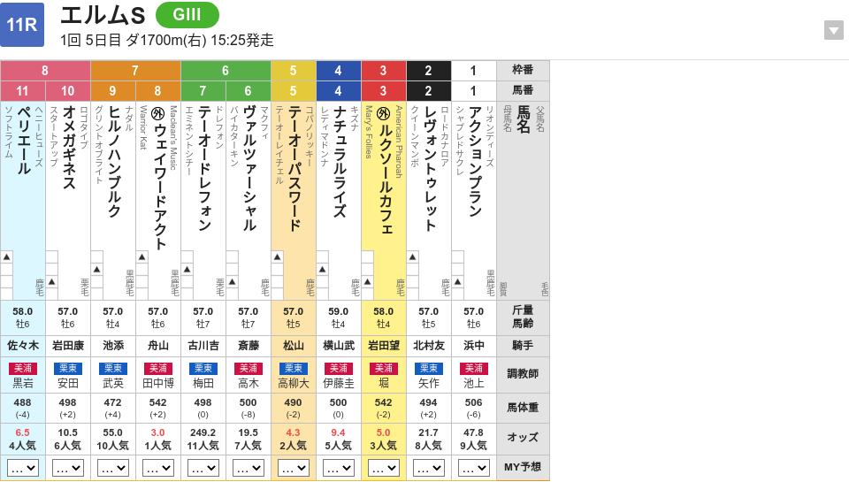

### 【レパードステークス 2026/08/09(日) 】

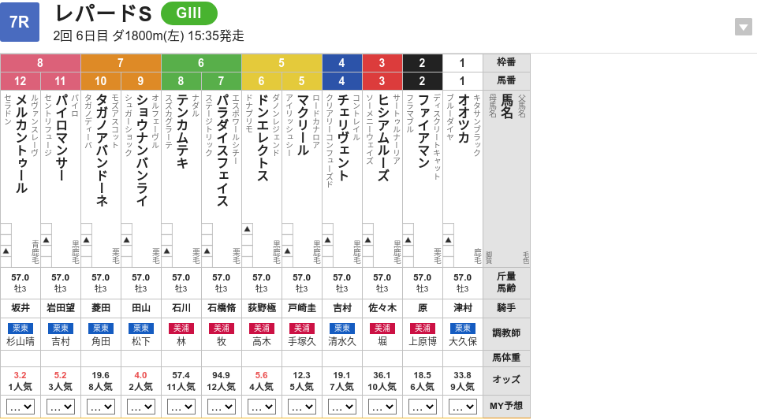

### 【CBC賞 2026/08/09(日) 】

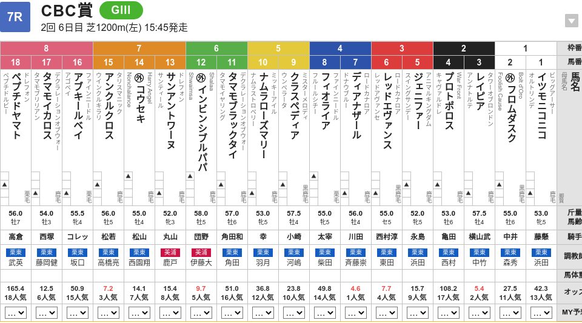

## 4. 単勝予測結果

### 【エルムステークス(GⅢ) 2026/08/08(土)】

| 枠番 | 馬番 | 人気 | オッズ | 馬名 | 騎手 | 調教師 | 予測タイム(sec) | 1_順位 | 1-3着内確率(%) | 2_順位 | ﾀﾞｰｸﾎｰｽ確率(%) | 3_順位 |
| --- | --- | --- | --- | --- | --- | --- | --- | --- | --- | --- | --- | --- |
| 1 | 1 | 9 | 47.8 | アクションプラン | 浜中俊 | 池上昌和 | 113.4 | 9 | 3.0 | 11 | 12.0 | 4 |
| 2 | 2 | 8 | 21.7 | レヴォントゥレット | 北村友一 | 矢作芳人 | 104.2 | 4 | 16.2 | 7 | 44.2 | 1 |
| 3 | 3 | 3 | 5.0 | ルクソールカフェ | 岩田望来 | 堀宣行 | 103.7 | 2 | 39.9 | 2 | 0.5 | 8 |
| 4 | 4 | 5 | 9.4 | ナチュラルライズ | 横山武史 | 伊藤圭三 | 115.6 | 11 | 33.4 | 3 | 0.9 | 7 |
| 5 | 5 | 2 | 4.3 | テーオーパスワード | 松山弘平 | 高柳大輔 | 104.7 | 5 | 49.2 | 1 | 0.4 | 9 |
| 6 | 6 | 7 | 19.5 | ヴァルツァーシャル | 斎藤新 | 高木登 | 113.6 | 10 | 6.7 | 10 | 9.3 | 5 |
| 6 | 7 | 11 | 249.2 | テーオードレフォン | 古川吉洋 | 梅田智之 | 113.1 | 8 | 7.0 | 9 | 28.5 | 3 |
| 7 | 8 | 1 | 3.0 | ウェイワードアクト | 舟山瑠泉 | 田中博康 | 100.9 | 1 | 25.8 | 5 | 0.4 | 10 |
| 7 | 9 | 10 | 55.0 | ヒルノハンブルク | 池添謙一 | 武英智 | 104.1 | 3 | 11.0 | 8 | 41.3 | 2 |
| 8 | 10 | 6 | 10.5 | オメガギネス | 岩田康誠 | 安田翔伍 | 107.4 | 6 | 18.6 | 6 | 1.1 | 6 |

[output cut: 1 more lines]

### 【レパードステークス(GⅢ) 2026/08/09(日)】

| 枠番 | 馬番 | 人気 | オッズ | 馬名 | 騎手 | 調教師 | 予測タイム(sec) | 1_順位 | 1-3着内確率(%) | 2_順位 | ﾀﾞｰｸﾎｰｽ確率(%) | 3_順位 |
| --- | --- | --- | --- | --- | --- | --- | --- | --- | --- | --- | --- | --- |
| 1 | 1 | 9 | 33.4 | オオツカ | 津村明秀 | 大久保龍志 | 120.0 | 11 | 3.0 | 11 | 10.0 | 5 |
| 2 | 2 | 6 | 18.9 | ファイアマン | 原優介 | 上原博之 | 119.8 | 9 | 4.2 | 9 | 0.8 | 9 |
| 3 | 3 | 10 | 35.8 | ヒシアムルーズ | 佐々木大輔 | 堀宣行 | 111.9 | 2 | 12.1 | 6 | 46.4 | 1 |
| 4 | 4 | 8 | 20.2 | チェリヴェント | 吉村誠之助 | 清水久詞 | 122.2 | 12 | 6.2 | 7 | 9.6 | 6 |
| 5 | 5 | 5 | 12.4 | マクリール | 戸崎圭太 | 手塚貴久 | 113.3 | 4 | 20.2 | 4 | 1.3 | 7 |
| 5 | 6 | 4 | 5.8 | ドンエレクトス | 荻野極 | 高木登 | 119.9 | 10 | 20.8 | 3 | 0.9 | 8 |
| 6 | 7 | 12 | 93.3 | パラダイスフェイス | 石橋脩 | 牧光二 | 119.4 | 5 | 5.2 | 8 | 12.1 | 3 |
| 6 | 8 | 11 | 57.3 | テンカムテキ | 石川裕紀人 | 林徹 | 119.5 | 6 | 2.3 | 12 | 24.2 | 2 |
| 7 | 9 | 2 | 4.0 | ショウナンバンライ | 田山旺佑 | 松下武士 | 119.7 | 8 | 30.7 | 2 | 0.4 | 11 |
| 7 | 10 | 7 | 20.0 | タガノアバンドーネ | 菱田裕二 | 角田晃一 | 119.7 | 7 | 3.4 | 10 | 12.0 | 4 |

[output cut: 2 more lines]

### 【CBC賞(GⅢ) 2026/08/09(日)】

| 枠番 | 馬番 | 人気 | オッズ | 馬名 | 騎手 | 調教師 | 予測タイム(sec) | 1_順位 | 1-3着内確率(%) | 2_順位 | ﾀﾞｰｸﾎｰｽ確率(%) | 3_順位 |
| --- | --- | --- | --- | --- | --- | --- | --- | --- | --- | --- | --- | --- |
| 1 | 1 | 13 | 41.8 | イツモニコニコ | 藤懸貴志 | 浜田多実雄 | 71.9 | 10 | 10.9 | 11 | 33.5 | 5 |
| 1 | 2 | 11 | 27.0 | フロムダスク | 中井裕二 | 森秀行 | 76.1 | 12 | 2.9 | 16 | 9.7 | 9 |
| 2 | 3 | 2 | 5.4 | レイピア | 横山武史 | 中竹和也 | 71.3 | 9 | 47.2 | 1 | 0.4 | 18 |
| 2 | 4 | 17 | 106.0 | プロトポロス | 亀田温心 | 西村真幸 | 67.0 | 2 | 18.0 | 6 | 49.1 | 1 |
| 3 | 5 | 9 | 15.5 | ジェニファー | 永島まなみ | 浜田多実雄 | 76.4 | 14 | 5.9 | 14 | 0.8 | 14 |
| 3 | 6 | 4 | 7.7 | レッドエヴァンス | 西村淳也 | 東田明士 | 77.6 | 18 | 13.5 | 9 | 0.6 | 15 |
| 4 | 7 | 1 | 4.6 | ディアナザール | 川田将雅 | 斉藤崇史 | 67.0 | 2 | 19.4 | 5 | 0.4 | 17 |
| 4 | 8 | 14 | 49.4 | フィオライア | 太宰啓介 | 柴田卓 | 68.2 | 4 | 10.8 | 12 | 46.1 | 2 |
| 5 | 9 | 10 | 23.4 | クラスペディア | 小崎綾也 | 河嶋宏樹 | 69.4 | 8 | 14.1 | 8 | 26.6 | 6 |
| 5 | 10 | 12 | 36.5 | ナムラローズマリー | 幸英明 | 羽月友彦 | 76.3 | 13 | 2.5 | 17 | 14.0 | 8 |

[output cut: 8 more lines]

## 5. 人気と着順の乖離率推移

### 【エルムステークス_1997y_2019y】

[interactive chart not shown]

### 【レパードステークス_2011y_2019y】

[interactive chart not shown]

### 【CBC賞_1990y_2019y】

[interactive chart not shown]

### 【エルムステークス_1997y_2019y】

| No | 開催年 | 不整合率(%) | 頭数 | 人気別着順(1-3位) | 人気別着順(全体) |
| --- | --- | --- | --- | --- | --- |
| 23 | 2019 | 46.2 | 14頭 | 2-10-4 | 2\|10\|4\|7\|3\|5\|1\|6\|14\|11\|8\|12\|13\|9 |
| 22 | 2018 | 32.4 | 14頭 | 2-3-1 | 2\|3\|1\|5\|7\|4\|11\|8\|10\|9\|14\|12\|6\|13 |
| 21 | 2017 | 32.3 | 14頭 | 4-1-8 | 4\|1\|8\|6\|13\|10\|2\|7\|12\|3\|9\|5\|11\|14 |
| 20 | 2016 | 45.5 | 12頭 | 7-4-1 | 7\|4\|1\|3\|8\|6\|2\|12\|11\|10\|9\|5 |
| 19 | 2015 | 31.6 | 13頭 | 2-5-7 | 2\|5\|7\|1\|3\|11\|6\|10\|8\|12\|13\|4\|9 |
| 18 | 2014 | 47.5 | 13頭 | 3-5-10 | 3\|5\|10\|12\|13\|1\|4\|7\|8\|2\|6\|11\|9 |
| 17 | 2013 | 48.9 | 13頭 | 3-5-1 | 3\|5\|1\|7\|4\|10\|9\|12\|6\|13\|11\|2\|8 |
| 16 | 2012 | 21.5 | 11頭 | 1-2-6 | 1\|2\|6\|4\|9\|8\|7\|5\|3\|10\|11 |
| 15 | 2011 | 34.3 | 13頭 | 1-8-3 | 1\|8\|3\|5\|4\|7\|6\|13\|9\|10\|2\|11\|12 |
| 14 | 2010 | 28.3 | 13頭 | 2-4-1 | 2\|4\|1\|13\|3\|6\|7\|5\|12\|9\|10\|8\|11 |

[output cut: 13 more lines]

### 【レパードステークス_2011y_2019y】

| No | 開催年 | 不整合率(%) | 頭数 | 人気別着順(1-3位) | 人気別着順(全体) |
| --- | --- | --- | --- | --- | --- |
| 9 | 2019 | 28.1 | 15頭 | 10-1-11 | 10\|1\|11\|7\|3\|2\|12\|9\|13\|4\|5\|8\|6\|14\|15 |
| 8 | 2018 | 43.0 | 15頭 | 5-10-9 | 5\|10\|9\|2\|4\|1\|11\|14\|3\|12\|6\|7\|8\|13\|15 |
| 7 | 2017 | 41.3 | 14頭 | 11-12-1 | 11\|12\|1\|13\|8\|4\|3\|9\|5\|7\|10\|2\|15\|6 |
| 6 | 2016 | 29.6 | 13頭 | 2-1-6 | 2\|1\|6\|4\|13\|5\|3\|10\|11\|8\|7\|12\|9 |
| 5 | 2015 | 23.5 | 14頭 | 1-3-11 | 1\|3\|11\|2\|6\|5\|12\|4\|8\|7\|14\|13\|15\|9 |
| 4 | 2014 | 13.6 | 15頭 | 1-7-9 | 1\|7\|9\|2\|3\|4\|10\|8\|12\|5\|14\|13\|15\|6\|11 |
| 3 | 2013 | 17.1 | 15頭 | 1-4-2 | 1\|4\|2\|3\|13\|6\|8\|9\|5\|11\|7\|15\|12\|14\|10 |
| 2 | 2012 | 30.0 | 15頭 | 2-3-1 | 2\|3\|1\|4\|10\|6\|12\|5\|13\|8\|14\|9\|11\|7\|15 |
| 1 | 2011 | 18.3 | 15頭 | 1-2-12 | 1\|2\|12\|3\|10\|7\|8\|6\|14\|5\|13\|11\|4\|9\|15 |

### 【CBC賞_1990y_2019y】

| No | 開催年 | 不整合率(%) | 頭数 | 人気別着順(1-3位) | 人気別着順(全体) |
| --- | --- | --- | --- | --- | --- |
| 30 | 2019 | 21.5 | 13頭 | 1-7-2 | 1\|7\|2\|8\|5\|6\|11\|3\|12\|9\|10\|4\|13 |
| 29 | 2018 | 59.6 | 18頭 | 4-9-8 | 4\|9\|8\|3\|13\|15\|10\|11\|6\|14\|1\|12\|7\|18\|2\|5\|17\|16 |
| 28 | 2017 | 30.9 | 18頭 | 2-13-8 | 2\|13\|8\|9\|12\|15\|17\|11\|16\|1\|3\|10\|4\|6\|14\|5\|7\|18 |
| 27 | 2016 | 63.8 | 13頭 | 3-7-2 | 3\|7\|2\|6\|10\|5\|8\|4\|1\|13\|11\|9\|12 |
| 26 | 2015 | 22.4 | 17頭 | 2-1-3 | 2\|1\|3\|5\|17\|14\|9\|8\|4\|12\|15\|6\|13\|11\|16\|7\|10 |
| 25 | 2014 | 51.7 | 16頭 | 4-3-10 | 4\|3\|10\|9\|1\|8\|15\|2\|6\|7\|16\|11\|13\|14\|12\|5 |
| 24 | 2013 | 7.4 | 14頭 | 1-2-3 | 1\|2\|3\|5\|4\|8\|7\|10\|11\|6\|14\|9\|12\|13 |
| 23 | 2012 | 32.0 | 17頭 | 2-7-1 | 2\|7\|1\|8\|4\|10\|5\|6\|3\|9\|12\|15\|13\|16\|17\|14\|11 |
| 22 | 2011 | 33.9 | 16頭 | 1-4-13 | 1\|4\|13\|5\|3\|6\|7\|2\|12\|9\|10\|15\|14\|11\|8\|16 |
| 21 | 2010 | 57.5 | 18頭 | 4-7-3 | 4\|7\|3\|12\|13\|1\|10\|8\|11\|6\|18\|16\|5\|2\|17\|14\|15\|9 |

[output cut: 20 more lines]

## 6. 1-3番人気馬の着順分類予測

### 【エルムステークス】

| 分類 | 凡例 | 発生確率(%) | 当該レース | 当該レースランク | 直近1年間 |
| --- | --- | --- | --- | --- | --- |
| 1: 1番人気のみ (1_pop1) | 1 \| * \| * | 18.6 | 1.35 | 0.85 | 0.56 |
| 4: 1,2番人気のみ (4_pop12) | 1 \| 2 \| * | 18.1 | 1.05 | 0.72 | 0.54 |
| 8: 1,2,3番人気すべて着外 (8_darkhorse) | * \| * \| * | 14.2 | 4.18 | 2.29 | 0.00 |
| 5: 1,3番人気のみ (5_pop13) | 1 \| 3 \| * | 13.4 | 1.30 | 2.16 | 0.00 |
| 2: 2番人気のみ (2_pop2) | 2 \| * \| * | 10.2 | 0.30 | 0.50 | 0.31 |
| 6: 2,3番人気のみ (6_pop23) | 2 \| 3 \| * | 10.0 | 2.94 | 3.23 | 0.00 |
| 3: 3番人気のみ (3_pop3) | 3 \| * \| * | 8.4 | 0.82 | 0.89 | 0.00 |
| 7: 1,2,3番人気すべて着内 (7_pop123) | 1 \| 2 \| 3 | 7.1 | 1.03 | 0.91 | 0.00 |

### 【レパードステークス】

| 分類 | 凡例 | 発生確率(%) | 当該レース | 当該レースランク | 直近1年間 |
| --- | --- | --- | --- | --- | --- |
| 1: 1番人気のみ (1_pop1) | 1 \| * \| * | 18.6 | 0.31 | 0.65 | 0.37 |
| 4: 1,2番人気のみ (4_pop12) | 1 \| 2 \| * | 18.1 | 0.90 | 0.58 | 0.36 |
| 8: 1,2,3番人気すべて着外 (8_darkhorse) | * \| * \| * | 14.2 | 2.12 | 1.65 | 0.00 |
| 5: 1,3番人気のみ (5_pop13) | 1 \| 3 \| * | 13.4 | 2.00 | 4.62 | 0.00 |
| 2: 2番人気のみ (2_pop2) | 2 \| * \| * | 10.2 | 0.00 | 1.19 | 0.00 |
| 6: 2,3番人気のみ (6_pop23) | 2 \| 3 \| * | 10.0 | 0.00 | 3.45 | 0.00 |
| 3: 3番人気のみ (3_pop3) | 3 \| * \| * | 8.4 | 0.00 | 0.98 | 0.00 |
| 7: 1,2,3番人気すべて着内 (7_pop123) | 1 \| 2 \| 3 | 7.1 | 1.06 | 0.83 | 0.00 |

### 【CBC賞】

| 分類 | 凡例 | 発生確率(%) | 当該レース | 当該レースランク | 直近1年間 |
| --- | --- | --- | --- | --- | --- |
| 1: 1番人気のみ (1_pop1) | 1 \| * \| * | 21.0 | 1.89 | 0.73 | 0.42 |
| 4: 1,2番人気のみ (4_pop12) | 1 \| 2 \| * | 17.7 | 0.58 | 0.56 | 0.35 |
| 8: 1,2,3番人気すべて着外 (8_darkhorse) | * \| * \| * | 13.9 | 1.67 | 1.62 | 0.00 |
| 5: 1,3番人気のみ (5_pop13) | 1 \| 3 \| * | 13.5 | 2.41 | 4.66 | 0.00 |
| 6: 2,3番人気のみ (6_pop23) | 2 \| 3 \| * | 9.8 | 1.75 | 3.38 | 0.00 |
| 2: 2番人気のみ (2_pop2) | 2 \| * \| * | 9.1 | 0.82 | 1.06 | 0.00 |
| 3: 3番人気のみ (3_pop3) | 3 \| * \| * | 8.1 | 0.58 | 0.94 | 0.00 |
| 7: 1,2,3番人気すべて着内 (7_pop123) | 1 \| 2 \| 3 | 6.9 | 0.50 | 0.80 | 0.00 |

## 7. 3連複予測結果

### 【エルムステークス(GⅢ) 2026/08/08(土)】

| 分類 | 馬番 | 枠番 | 人気 | 平均予測タイム(sec) | 1-3着内確率(%) | ﾀﾞｰｸﾎｰｽ確率(%) | 馬名 | 騎手 | 調教師 |
| --- | --- | --- | --- | --- | --- | --- | --- | --- | --- |
| 6: 2,3番人気のみ (6_pop23) | 5-3-4 | 5-3-4 | 2-3-5 | 108.00 | 6.56 | 0.00 | テーオーパスワード \| ルクソールカフェ \| ナチュラルライズ | 松山弘平 \| 岩田望来 \| 横山武史 | 高柳大輔 \| 堀宣行 \| 伊藤圭三 |
| 6: 2,3番人気のみ (6_pop23) | 5-3-11 | 5-3-8 | 2-3-4 | 105.27 | 5.52 | 0.00 | テーオーパスワード \| ルクソールカフェ \| ペリエール | 松山弘平 \| 岩田望来 \| 佐々木大輔 | 高柳大輔 \| 堀宣行 \| 黒岩陽一 |
| 7: 1,2,3番人気すべて着内 (7_pop123) | 8-5-3 | 7-5-3 | 1-2-3 | 103.10 | 5.06 | 0.00 | ウェイワードアクト \| テーオーパスワード \| ルクソールカフェ | 舟山瑠泉 \| 松山弘平 \| 岩田望来 | 田中博康 \| 高柳大輔 \| 堀宣行 |
| 2: 2番人気のみ (2_pop2) | 5-11-4 | 5-8-4 | 2-4-5 | 109.23 | 4.62 | 0.00 | テーオーパスワード \| ペリエール \| ナチュラルライズ | 松山弘平 \| 佐々木大輔 \| 横山武史 | 高柳大輔 \| 黒岩陽一 \| 伊藤圭三 |
| 4: 1,2番人気のみ (4_pop12) | 8-5-4 | 7-5-4 | 1-2-5 | 107.07 | 4.24 | 0.00 | ウェイワードアクト \| テーオーパスワード \| ナチュラルライズ | 舟山瑠泉 \| 松山弘平 \| 横山武史 | 田中博康 \| 高柳大輔 \| 伊藤圭三 |
| 3: 3番人気のみ (3_pop3) | 3-11-4 | 3-8-4 | 3-4-5 | 108.90 | 3.75 | 0.00 | ルクソールカフェ \| ペリエール \| ナチュラルライズ | 岩田望来 \| 佐々木大輔 \| 横山武史 | 堀宣行 \| 黒岩陽一 \| 伊藤圭三 |
| 6: 2,3番人気のみ (6_pop23) | 5-3-10 | 5-3-8 | 2-3-6 | 105.27 | 3.66 | 0.00 | テーオーパスワード \| ルクソールカフェ \| オメガギネス | 松山弘平 \| 岩田望来 \| 岩田康誠 | 高柳大輔 \| 堀宣行 \| 安田翔伍 |
| 4: 1,2番人気のみ (4_pop12) | 8-5-11 | 7-5-8 | 1-2-4 | 104.33 | 3.56 | 0.00 | ウェイワードアクト \| テーオーパスワード \| ペリエール | 舟山瑠泉 \| 松山弘平 \| 佐々木大輔 | 田中博康 \| 高柳大輔 \| 黒岩陽一 |
| 5: 1,3番人気のみ (5_pop13) | 8-3-4 | 7-3-4 | 1-3-5 | 106.73 | 3.44 | 0.00 | ウェイワードアクト \| ルクソールカフェ \| ナチュラルライズ | 舟山瑠泉 \| 岩田望来 \| 横山武史 | 田中博康 \| 堀宣行 \| 伊藤圭三 |
| 6: 2,3番人気のみ (6_pop23) | 5-3-2 | 5-3-2 | 2-3-8 | 104.20 | 3.18 | 0.00 | テーオーパスワード \| ルクソールカフェ \| レヴォントゥレット | 松山弘平 \| 岩田望来 \| 北村友一 | 高柳大輔 \| 堀宣行 \| 矢作芳人 |

[output cut: 155 more lines]

### 【レパードステークス(GⅢ) 2026/08/09(日)】

| 分類 | 馬番 | 枠番 | 人気 | 平均予測タイム(sec) | 1-3着内確率(%) | ﾀﾞｰｸﾎｰｽ確率(%) | 馬名 | 騎手 | 調教師 |
| --- | --- | --- | --- | --- | --- | --- | --- | --- | --- |
| 6: 2,3番人気のみ (6_pop23) | 9-11-6 | 7-8-5 | 2-3-4 | 117.50 | 2.23 | 0.00 | ショウナンバンライ \| パイロマンサー \| ドンエレクトス | 田山旺佑 \| 岩田望来 \| 荻野極 | 松下武士 \| 吉村圭司 \| 高木登 |
| 6: 2,3番人気のみ (6_pop23) | 9-11-5 | 7-8-5 | 2-3-5 | 115.30 | 2.17 | 0.00 | ショウナンバンライ \| パイロマンサー \| マクリール | 田山旺佑 \| 岩田望来 \| 戸崎圭太 | 松下武士 \| 吉村圭司 \| 手塚貴久 |
| 7: 1,2,3番人気すべて着内 (7_pop123) | 12-9-11 | 8-7-8 | 1-2-3 | 114.30 | 1.74 | 0.00 | メルカントゥール \| ショウナンバンライ \| パイロマンサー | 坂井瑠星 \| 田山旺佑 \| 岩田望来 | 杉山晴紀 \| 松下武士 \| 吉村圭司 |
| 3: 3番人気のみ (3_pop3) | 11-6-5 | 8-5-5 | 3-4-5 | 115.37 | 1.47 | 0.00 | パイロマンサー \| ドンエレクトス \| マクリール | 岩田望来 \| 荻野極 \| 戸崎圭太 | 吉村圭司 \| 高木登 \| 手塚貴久 |
| 6: 2,3番人気のみ (6_pop23) | 9-11-3 | 7-8-3 | 2-3-10 | 114.83 | 1.30 | 0.00 | ショウナンバンライ \| パイロマンサー \| ヒシアムルーズ | 田山旺佑 \| 岩田望来 \| 佐々木大輔 | 松下武士 \| 吉村圭司 \| 堀宣行 |
| 2: 2番人気のみ (2_pop2) | 9-6-5 | 7-5-5 | 2-4-5 | 117.63 | 1.29 | 0.00 | ショウナンバンライ \| ドンエレクトス \| マクリール | 田山旺佑 \| 荻野極 \| 戸崎圭太 | 松下武士 \| 高木登 \| 手塚貴久 |
| 5: 1,3番人気のみ (5_pop13) | 12-11-6 | 8-8-5 | 1-3-4 | 114.37 | 1.18 | 0.00 | メルカントゥール \| パイロマンサー \| ドンエレクトス | 坂井瑠星 \| 岩田望来 \| 荻野極 | 杉山晴紀 \| 吉村圭司 \| 高木登 |
| 5: 1,3番人気のみ (5_pop13) | 12-11-5 | 8-8-5 | 1-3-5 | 112.17 | 1.15 | 0.00 | メルカントゥール \| パイロマンサー \| マクリール | 坂井瑠星 \| 岩田望来 \| 戸崎圭太 | 杉山晴紀 \| 吉村圭司 \| 手塚貴久 |
| 4: 1,2番人気のみ (4_pop12) | 12-9-6 | 8-7-5 | 1-2-4 | 116.63 | 1.04 | 0.00 | メルカントゥール \| ショウナンバンライ \| ドンエレクトス | 坂井瑠星 \| 田山旺佑 \| 荻野極 | 杉山晴紀 \| 松下武士 \| 高木登 |
| 4: 1,2番人気のみ (4_pop12) | 12-9-5 | 8-7-5 | 1-2-5 | 114.43 | 1.01 | 0.00 | メルカントゥール \| ショウナンバンライ \| マクリール | 坂井瑠星 \| 田山旺佑 \| 戸崎圭太 | 杉山晴紀 \| 松下武士 \| 手塚貴久 |

[output cut: 210 more lines]

### 【CBC賞(GⅢ) 2026/08/09(日)】

| 分類 | 馬番 | 枠番 | 人気 | 平均予測タイム(sec) | 1-3着内確率(%) | ﾀﾞｰｸﾎｰｽ確率(%) | 馬名 | 騎手 | 調教師 |
| --- | --- | --- | --- | --- | --- | --- | --- | --- | --- |
| 2: 2番人気のみ (2_pop2) | 3-12-17 | 2-6-8 | 2-5-6 | 69.60 | 2.51 | 0.00 | レイピア \| インビンシブルパパ \| タマモイカロス | 横山武史 \| 団野大成 \| 西塚洸二 | 中竹和也 \| 伊藤大士 \| 藤岡健一 |
| 2: 2番人気のみ (2_pop2) | 3-12-13 | 2-6-7 | 2-5-8 | 69.63 | 2.28 | 0.00 | レイピア \| インビンシブルパパ \| サンアントワーヌ | 横山武史 \| 団野大成 \| 丸山元気 | 中竹和也 \| 伊藤大士 \| 鹿戸雄一 |
| 4: 1,2番人気のみ (4_pop12) | 7-3-12 | 4-2-6 | 1-2-5 | 68.87 | 2.25 | 0.00 | ディアナザール \| レイピア \| インビンシブルパパ | 川田将雅 \| 横山武史 \| 団野大成 | 斉藤崇史 \| 中竹和也 \| 伊藤大士 |
| 2: 2番人気のみ (2_pop2) | 3-12-4 | 2-6-2 | 2-5-17 | 68.87 | 2.08 | 0.00 | レイピア \| インビンシブルパパ \| プロトポロス | 横山武史 \| 団野大成 \| 亀田温心 | 中竹和也 \| 伊藤大士 \| 西村真幸 |
| 2: 2番人気のみ (2_pop2) | 3-17-13 | 2-8-7 | 2-6-8 | 69.93 | 2.02 | 0.00 | レイピア \| タマモイカロス \| サンアントワーヌ | 横山武史 \| 西塚洸二 \| 丸山元気 | 中竹和也 \| 藤岡健一 \| 鹿戸雄一 |
| 4: 1,2番人気のみ (4_pop12) | 7-3-17 | 4-2-8 | 1-2-6 | 69.17 | 1.99 | 0.00 | ディアナザール \| レイピア \| タマモイカロス | 川田将雅 \| 横山武史 \| 西塚洸二 | 斉藤崇史 \| 中竹和也 \| 藤岡健一 |
| 6: 2,3番人気のみ (6_pop23) | 3-15-12 | 2-7-6 | 2-3-5 | 72.30 | 1.89 | 0.00 | レイピア \| アンクルクロス \| インビンシブルパパ | 横山武史 \| 松若風馬 \| 団野大成 | 中竹和也 \| 高橋亮 \| 伊藤大士 |
| 2: 2番人気のみ (2_pop2) | 3-17-4 | 2-8-2 | 2-6-17 | 69.17 | 1.84 | 0.00 | レイピア \| タマモイカロス \| プロトポロス | 横山武史 \| 西塚洸二 \| 亀田温心 | 中竹和也 \| 藤岡健一 \| 西村真幸 |
| 4: 1,2番人気のみ (4_pop12) | 7-3-13 | 4-2-7 | 1-2-8 | 69.20 | 1.81 | 0.00 | ディアナザール \| レイピア \| サンアントワーヌ | 川田将雅 \| 横山武史 \| 丸山元気 | 斉藤崇史 \| 中竹和也 \| 鹿戸雄一 |
| 6: 2,3番人気のみ (6_pop23) | 3-15-17 | 2-7-8 | 2-3-6 | 72.60 | 1.68 | 0.00 | レイピア \| アンクルクロス \| タマモイカロス | 横山武史 \| 松若風馬 \| 西塚洸二 | 中竹和也 \| 高橋亮 \| 藤岡健一 |

[output cut: 806 more lines]

## 8. 直近の全レース情報

[output not shown]